# Network Analysis of Sex Addiction and total scores of Depression, Anxiety and Stress

BH

2024-04-12

```r
library(bootnet)
library(haven)
library(networktools)
library(NetworkComparisonTest)
library(qgraph)
library(tidyverse)
library(naniar)
library(mice)
library(VIM)
library(psych)
library(formatR)
library(haven)
library(bnlearn)
library(bnviewer)
library(igraph)
library(dplyr)
library(GPArotation)
```

#Set working directory and load dataset as Data <- read_sav(“provide file location”)

```r
## How many participants by category?

Data %>%
    group_by(Category) %>%
    count()
```

```
## # A tibble: 3 × 2
## # Groups:   Category [3]
##   Category     n
##      <int> <int>
## 1        1   211
## 2        2   529
## 3        3   194
```

#Percentage of missing data in the dataset

```r
D1 <- Data %>%
    select(11, 113:118, 192:212)

## This calculates % of missing data
totalcells <- prod(dim(D1))
missingcells <- sum(is.na(D1))
perc <- (missingcells * 100)/(totalcells)
perc
```

```
## [1] 0.152952
```

```r
mcar_test(D1)
```

```
## # A tibble: 1 × 4
##   statistic    df   p.value missing.patterns
##       <dbl> <dbl>     <dbl>            <int>
## 1      769.   619 0.0000360               24
```

#Variables with highest number of missing values

```r
D1 %>%
    select(!1) %>%
    summarise(across(everything(), ~sum(is.na(.)))) %>%
    pivot_longer(cols = everything(), names_to = "names", values_to = "values") %>%
    arrange(desc(values)) %>%
    mutate(perc = (values)/934) %>%
    slice_head(n = 13)
```

```
## # A tibble: 13 × 3
##    names values    perc
##    <chr>  <int>   <dbl>
##  1 DS3        4 0.00428
##  2 DS6        4 0.00428
##  3 DS12       4 0.00428
##  4 DS7        3 0.00321
##  5 DS21       3 0.00321
##  6 SX2        2 0.00214
##  7 SX4        2 0.00214
##  8 DS8        2 0.00214
##  9 DS13       2 0.00214
## 10 DS16       2 0.00214
## 11 DS19       2 0.00214
## 12 SX3        1 0.00107
## 13 SX5        1 0.00107
```

```r
## Data imputation with Predictive Mean Matching (PMM) and 50 iterations D2 <-
## sapply(D1, haven::zap_labels) ## this line converts doubles into integers
## imputed_data <- mice(D2, m=5, maxit = 50, method = 'pmm', seed = 500)
## summary(imputed_data) completeData <- as_tibble(complete(imputed_data,2))

# write_sav(completeData, 'Complete_data.sav') write.csv(completeData,
# 'complete.csv')
```

Define categories for analysis

```r
## Remove first column and calculate total DAS items. Remove individual
## symptoms of DASS
D3 <- read.csv("Complete1.csv")

view(D3)

D4 <- D3 %>%
    select(!Category)

Female_hetero <- D3 %>%
    filter(Category == 1) %>%
    select(!Category)

Male_hetero <- D3 %>%
    filter(Category == 2) %>%
    select(!Category)

LGBTQ <- D3 %>%
    filter(Category == 3) %>%
    select(!Category)
```

#Estimate network

```r
network1 <- estimateNetwork(D4, default = "EBICglasso")
network1
```

```
##
## === Estimated network ===
## Number of nodes: 9
## Number of non-zero edges: 23 / 36
## Mean weight: 0.1045825
## Network stored in x$graph
##
## Default set used: EBICglasso
##
## Use plot(x) to plot estimated network
## Use bootnet(x) to bootstrap edge weights and centrality indices
##
## Relevant references:
##
##      Friedman, J. H., Hastie, T., & Tibshirani, R. (2008). Sparse inverse covariance estimation with the graphical lasso. Biostatistics, 9 (3), 432-441.
##  Foygel, R., & Drton, M. (2010). Extended Bayesian information criteria for Gaussian graphical models.
##  Friedman, J. H., Hastie, T., & Tibshirani, R. (2014). glasso: Graphical lasso estimation of gaussian graphical models. Retrieved from https://CRAN.R-project.org/package=glasso
##  Epskamp, S., Cramer, A., Waldorp, L., Schmittmann, V. D., & Borsboom, D. (2012). qgraph: Network visualizations of relationships in psychometric data. Journal of Statistical Software, 48 (1), 1-18.
##  Epskamp, S., Borsboom, D., & Fried, E. I. (2016). Estimating psychological networks and their accuracy: a tutorial paper. arXiv preprint, arXiv:1604.08462.
```

Conduct bootstrapping to determine stability of resulting network

```r
# b1 <- bootnet(network1, boots=1000, type='nonparametric', nCores = 8,
# statistics=c('strength', 'expectedInfluence', 'edge')) b2 <-
# bootnet(network1, boots=1000, type='case', nCores = 8, statistics =
# c('strength','expectedInfluence'))

# saveRDS(b1, file = 'b1.RDS') saveRDS(b2, file = 'b2.RDS')
b1 <- readRDS("b1.RDS")
b2 <- readRDS("b2.RDS")
```

#Correlation stability coefficient and plot CS larger than 0.7 is excellent, 0.5 < CS < 0.7 is acceptable, CS < 0.5 not acceptable

```r
corStability(b2)
```

```
## === Correlation Stability Analysis ===
##
## Sampling levels tested:
##    nPerson Drop%   n
## 1      234  74.9  90
## 2      306  67.2 110
## 3      379  59.4 102
## 4      451  51.7 109
## 5      524  43.9 100
## 6      597  36.1  95
## 7      669  28.4 103
## 8      742  20.6  99
## 9      815  12.7 109
## 10     887   5.0  83
##
## Maximum drop proportions to retain correlation of 0.7 in at least 95% of the samples:
##
## expectedInfluence: 0.749 (CS-coefficient is highest level tested)
##   - For more accuracy, run bootnet(..., caseMin = 0.672, caseMax = 1)
##
## strength: 0.749 (CS-coefficient is highest level tested)
##   - For more accuracy, run bootnet(..., caseMin = 0.672, caseMax = 1)
##
## Accuracy can also be increased by increasing both 'nBoots' and 'caseN'.
```

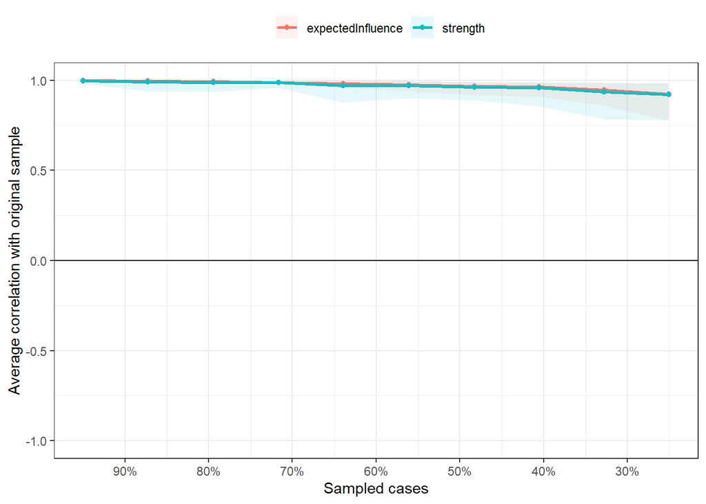

```r
plot(b2, "all")
```

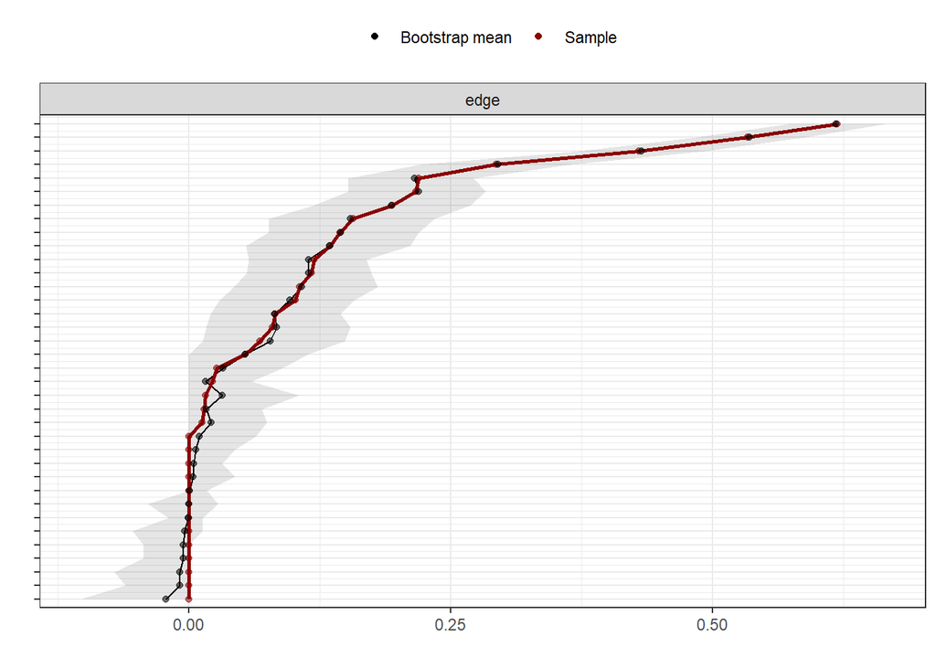

```r
# pdf('edge_stability.pdf')
plot(b1, labels = F, order = "sample")
```

#Define groups and legend for nodes

```r
groups1 <- list(BYSAS = c(1:6), Depression = c(7), Anxiety = c(8), Stress = c(9))
Names <- c("Think about sex", "Increased sexual urges", "Use sex to escape", "Unsuccessfully reduce sex",
    "Troubled if prohibited from sex", "Sex has negative impact", "Depression", "Anxiety",
    "Stress")
```

#Estimate and plot male_hetero network

```r
male_hetero_network <- as_tibble(getWmat(network_males_hetero <- estimateNetwork(Male_hetero,
    default = "EBICglasso")))

network_males_hetero
```

```
##
## === Estimated network ===
## Number of nodes: 9
## Number of non-zero edges: 24 / 36
## Mean weight: 0.1037863
## Network stored in x$graph
##
## Default set used: EBICglasso
##
## Use plot(x) to plot estimated network
## Use bootnet(x) to bootstrap edge weights and centrality indices
##
## Relevant references:
##
##      Friedman, J. H., Hastie, T., & Tibshirani, R. (2008). Sparse inverse covariance estimation with the graphical lasso. Biostatistics, 9 (3), 432-441.
##  Foygel, R., & Drton, M. (2010). Extended Bayesian information criteria for Gaussian graphical models.
##  Friedman, J. H., Hastie, T., & Tibshirani, R. (2014). glasso: Graphical lasso estimation of gaussian graphical models. Retrieved from https://CRAN.R-project.org/package=glasso
##  Epskamp, S., Cramer, A., Waldorp, L., Schmittmann, V. D., & Borsboom, D. (2012). qgraph: Network visualizations of relationships in psychometric data. Journal of Statistical Software, 48 (1), 1-18.
##  Epskamp, S., Borsboom, D., & Fried, E. I. (2016). Estimating psychological networks and their accuracy: a tutorial paper. arXiv preprint, arXiv:1604.08462.
```

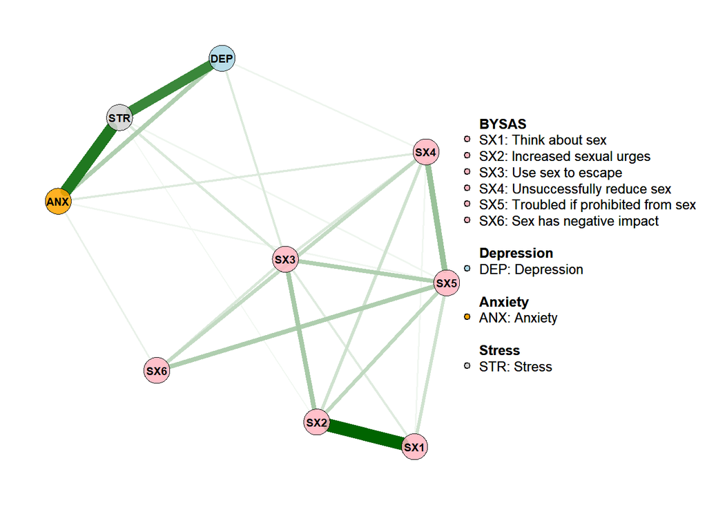

```r
qgraph(male_hetero_network, groups = groups1, nodeNames = Names, color = c("lightpink",
    "lightblue", "orange", "lightgrey"), layout = "spring", minimum = 0, cut = 0,
    curveAll = F, curveDefault = 0.5, label.color = "black", label.prop = 1, label.scale = T,
    label.scale.equal = T, legend.cex = 0.4, font = 2, vsize = 4, posCol = "dark green",
    borders = T, border.color = "black", border.width = 0.2, vTrans = 220, usePCH = F,
    node.resolution = 150)  #, filetype='tiff',filename='male_hetero_network')
```

#Estimate and plot female_hetero network

```r
female_hetero_network <- as_tibble(getWmat(network_female_hetero <- estimateNetwork(Female_hetero,
    default = "EBICglasso")))

network_female_hetero
```

```
##
## === Estimated network ===
## Number of nodes: 9
## Number of non-zero edges: 19 / 36
## Mean weight: 0.09479246
## Network stored in x$graph
##
## Default set used: EBICglasso
##
## Use plot(x) to plot estimated network
## Use bootnet(x) to bootstrap edge weights and centrality indices
##
## Relevant references:
##
##      Friedman, J. H., Hastie, T., & Tibshirani, R. (2008). Sparse inverse covariance estimation with the graphical lasso. Biostatistics, 9 (3), 432-441.
##  Foygel, R., & Drton, M. (2010). Extended Bayesian information criteria for Gaussian graphical models.
##  Friedman, J. H., Hastie, T., & Tibshirani, R. (2014). glasso: Graphical lasso estimation of gaussian graphical models. Retrieved from https://CRAN.R-project.org/package=glasso
##  Epskamp, S., Cramer, A., Waldorp, L., Schmittmann, V. D., & Borsboom, D. (2012). qgraph: Network visualizations of relationships in psychometric data. Journal of Statistical Software, 48 (1), 1-18.
##  Epskamp, S., Borsboom, D., & Fried, E. I. (2016). Estimating psychological networks and their accuracy: a tutorial paper. arXiv preprint, arXiv:1604.08462.
```

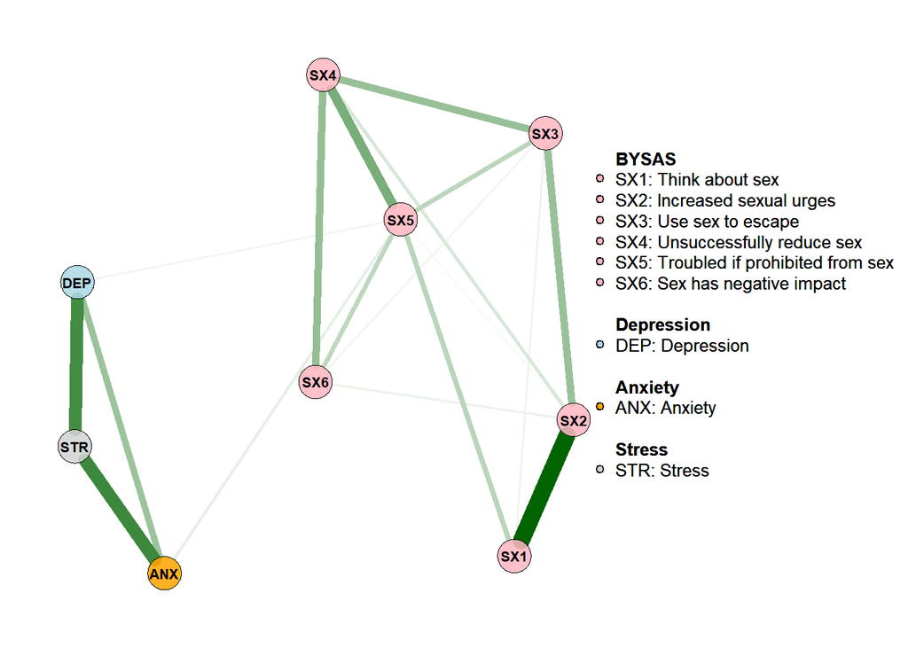

```r
qgraph(female_hetero_network, groups = groups1, nodeNames = Names, color = c("lightpink",
    "lightblue", "orange", "lightgrey"), layout = "spring", minimum = 0, cut = 0,
    curveAll = F, curveDefault = 0.5, label.color = "black", label.prop = 1, label.scale = T,
    label.scale.equal = T, legend.cex = 0.4, font = 2, vsize = 4, posCol = "dark green",
    borders = T, border.color = "black", border.width = 0.2, vTrans = 220, usePCH = F,
    node.resolution = 150)  # ,filetype='tiff',filename='female_hetero_network')
```

#Estimate and plot LGBTQ network

```r
LGBTQ_network <- as_tibble(getWmat(network_LGBTQ <- estimateNetwork(LGBTQ, default = "EBICglasso")))

network_LGBTQ
```

```
##
## === Estimated network ===
## Number of nodes: 9
## Number of non-zero edges: 21 / 36
## Mean weight: 0.1016298
## Network stored in x$graph
##
## Default set used: EBICglasso
##
## Use plot(x) to plot estimated network
## Use bootnet(x) to bootstrap edge weights and centrality indices
##
## Relevant references:
##
##      Friedman, J. H., Hastie, T., & Tibshirani, R. (2008). Sparse inverse covariance estimation with the graphical lasso. Biostatistics, 9 (3), 432-441.
##  Foygel, R., & Drton, M. (2010). Extended Bayesian information criteria for Gaussian graphical models.
##  Friedman, J. H., Hastie, T., & Tibshirani, R. (2014). glasso: Graphical lasso estimation of gaussian graphical models. Retrieved from https://CRAN.R-project.org/package=glasso
##  Epskamp, S., Cramer, A., Waldorp, L., Schmittmann, V. D., & Borsboom, D. (2012). qgraph: Network visualizations of relationships in psychometric data. Journal of Statistical Software, 48 (1), 1-18.
##  Epskamp, S., Borsboom, D., & Fried, E. I. (2016). Estimating psychological networks and their accuracy: a tutorial paper. arXiv preprint, arXiv:1604.08462.
```

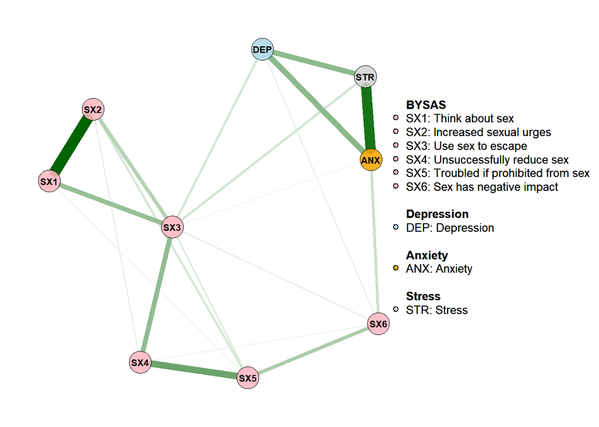

```r
qgraph(LGBTQ_network, groups = groups1, nodeNames = Names, color = c("lightpink",
    "lightblue", "orange", "lightgrey"), layout = "spring", minimum = 0, cut = 0,
    curveAll = F, curveDefault = 0.5, label.color = "black", label.prop = 1, label.scale = T,
    label.scale.equal = T, legend.cex = 0.4, font = 2, vsize = 4, posCol = "dark green",
    borders = T, border.color = "black", border.width = 0.2, vTrans = 220, usePCH = F,
    node.resolution = 150)  # ,filetype='tiff',filename='LGBTQnetwork')
```

#Network Comparison Test Male to Female

```r
set.seed(123)
Comparison_M_F <- NCT(network_males_hetero, network_female_hetero, gamma, it = 100,
    binary.data = FALSE, paired = FALSE, weighted = TRUE, AND = TRUE, test.edges = TRUE,
    edges = "ALL", progressbar = FALSE, test.centrality = TRUE)

Comparison_M_F
```

```
##
##  NETWORK INVARIANCE TEST
##  Test statistic M:
##  0.1468316
##  p-value 0.6435644
##
##  GLOBAL STRENGTH INVARIANCE TEST
##  Global strength per group:  3.736308 3.412528
##  Test statistic S:  0.3237798
##  p-value 0.1980198
##
##  EDGE INVARIANCE TEST
##    Var1 Var2    p-value Test statistic E
## 10  SX1  SX2 0.77227723       0.01594017
## 19  SX1  SX3 0.64356436       0.03627748
## 20  SX2  SX3 0.71287129       0.02906917
## 28  SX1  SX4 0.40594059       0.03525030
## 29  SX2  SX4 0.76237624       0.02180206
## 30  SX3  SX4 0.14851485       0.14683162
## 37  SX1  SX5 0.56435644       0.04411225
## 38  SX2  SX5 0.14851485       0.12205531
## 39  SX3  SX5 0.73267327       0.03034822
## 40  SX4  SX5 0.40594059       0.06876470
## 46  SX1  SX6 1.00000000       0.00000000
## 47  SX2  SX6 0.13861386       0.04517371
## 48  SX3  SX6 0.60396040       0.05163579
## 49  SX4  SX6 0.25742574       0.10089754
## 50  SX5  SX6 0.61386139       0.03730140
## 55  SX1  DEP 1.00000000       0.00000000
## 56  SX2  DEP 1.00000000       0.00000000
## 57  SX3  DEP 0.34653465       0.08014268
## 58  SX4  DEP 0.63366337       0.03903096
## 59  SX5  DEP 0.17821782       0.03147196
## 60  SX6  DEP 1.00000000       0.00000000
## 64  SX1  ANX 1.00000000       0.00000000
## 65  SX2  ANX 1.00000000       0.00000000
## 66  SX3  ANX 1.00000000       0.00000000
## 67  SX4  ANX 0.24752475       0.07212852
## 68  SX5  ANX 0.69306931       0.02302153
## 69  SX6  ANX 0.57425743       0.05098479
## 70  DEP  ANX 0.56435644       0.03933029
## 73  SX1  STR 1.00000000       0.00000000
## 74  SX2  STR 0.10891089       0.03118641
## 75  SX3  STR 0.04950495       0.08469067
## 76  SX4  STR 1.00000000       0.00000000
## 77  SX5  STR 0.42574257       0.03572432
## 78  SX6  STR 1.00000000       0.00000000
## 79  DEP  STR 0.62376238       0.03231821
## 80  ANX  STR 0.28712871       0.07563524
##
##  CENTRALITY INVARIANCE TEST p-value
##       strength expectedInfluence
## SX1 0.68316832        0.70297030
## SX2 0.23762376        0.22772277
## SX3 0.43564356        0.43564356
## SX4 0.34653465        0.26732673
## SX5 0.57425743        0.56435644
## SX6 0.98019802        0.97029703
## DEP 0.61386139        0.35643564
## ANX 0.25742574        0.23762376
## STR 0.02970297        0.01980198
```

#Network Comparison Test Male to LGBTQ

```r
set.seed(123)
Comparison_M_L <- NCT(network_males_hetero, network_LGBTQ, gamma, it = 100, binary.data = FALSE,
    paired = FALSE, weighted = TRUE, AND = TRUE, test.edges = TRUE, edges = "ALL",
    progressbar = FALSE, test.centrality = TRUE)

Comparison_M_L
```

```
##
##  NETWORK INVARIANCE TEST
##  Test statistic M:
##  0.1835436
##  p-value 0.2871287
##
##  GLOBAL STRENGTH INVARIANCE TEST
##  Global strength per group:  3.736308 3.658672
##  Test statistic S:  0.07763581
##  p-value 0.5742574
##
##  EDGE INVARIANCE TEST
##    Var1 Var2    p-value Test statistic E
## 10  SX1  SX2 0.82178218       0.01441678
## 19  SX1  SX3 0.04950495       0.17122268
## 20  SX2  SX3 0.79207921       0.02611891
## 28  SX1  SX4 0.57425743       0.03525030
## 29  SX2  SX4 0.49504950       0.05660491
## 30  SX3  SX4 0.03960396       0.17679851
## 37  SX1  SX5 0.34653465       0.07667757
## 38  SX2  SX5 0.55445545       0.04975064
## 39  SX3  SX5 0.18811881       0.10641775
## 40  SX4  SX5 0.26732673       0.11946898
## 46  SX1  SX6 1.00000000       0.00000000
## 47  SX2  SX6 1.00000000       0.00000000
## 48  SX3  SX6 0.79207921       0.03172610
## 49  SX4  SX6 0.33663366       0.10565247
## 50  SX5  SX6 0.89108911       0.01219744
## 55  SX1  DEP 1.00000000       0.00000000
## 56  SX2  DEP 1.00000000       0.00000000
## 57  SX3  DEP 0.78217822       0.02148939
## 58  SX4  DEP 0.36633663       0.03903096
## 59  SX5  DEP 1.00000000       0.00000000
## 60  SX6  DEP 0.06930693       0.04787720
## 64  SX1  ANX 1.00000000       0.00000000
## 65  SX2  ANX 1.00000000       0.00000000
## 66  SX3  ANX 0.36633663       0.03137441
## 67  SX4  ANX 0.13861386       0.07532235
## 68  SX5  ANX 0.19801980       0.03544932
## 69  SX6  ANX 0.28712871       0.07433767
## 70  DEP  ANX 0.25742574       0.08875765
## 73  SX1  STR 1.00000000       0.00000000
## 74  SX2  STR 0.05940594       0.03118641
## 75  SX3  STR 0.77227723       0.02000491
## 76  SX4  STR 1.00000000       0.00000000
## 77  SX5  STR 0.30693069       0.03572432
## 78  SX6  STR 1.00000000       0.00000000
## 79  DEP  STR 0.03960396       0.18354356
## 80  ANX  STR 0.50495050       0.03287413
##
##  CENTRALITY INVARIANCE TEST p-value
##       strength expectedInfluence
## SX1 0.51485149        0.48514851
## SX2 0.14851485        0.12871287
## SX3 0.04950495        0.04950495
## SX4 0.91089109        0.89108911
## SX5 0.11881188        0.11881188
## SX6 0.99009901        0.99009901
## DEP 0.54455446        0.45544554
## ANX 0.27722772        0.30693069
## STR 0.07920792        0.07920792
```

#Network Comparison Test Female to LGBTQ

```r
set.seed(123)
Comparison_F_L <- NCT(network_female_hetero, network_LGBTQ, gamma, it = 100, binary.data = FALSE,
    paired = FALSE, weighted = TRUE, AND = TRUE, test.edges = TRUE, edges = "ALL",
    progressbar = FALSE, test.centrality = TRUE)

Comparison_F_L
```

```
##
##  NETWORK INVARIANCE TEST
##  Test statistic M:
##  0.2075002
##  p-value 0.4059406
##
##  GLOBAL STRENGTH INVARIANCE TEST
##  Global strength per group:  3.412528 3.658672
##  Test statistic S:  0.2461439
##  p-value 0.1881188
##
##  EDGE INVARIANCE TEST
##    Var1 Var2    p-value Test statistic E
## 10  SX1  SX2 0.70297030       0.03035694
## 19  SX1  SX3 0.02970297       0.20750016
## 20  SX2  SX3 0.57425743       0.05518808
## 28  SX1  SX4 1.00000000       0.00000000
## 29  SX2  SX4 0.71287129       0.03480284
## 30  SX3  SX4 0.76237624       0.02996689
## 37  SX1  SX5 0.17821782       0.12078982
## 38  SX2  SX5 0.48514851       0.07230468
## 39  SX3  SX5 0.62376238       0.07606952
## 40  SX4  SX5 0.63366337       0.05070429
## 46  SX1  SX6 1.00000000       0.00000000
## 47  SX2  SX6 0.27722772       0.04517371
## 48  SX3  SX6 0.81188119       0.01990969
## 49  SX4  SX6 0.12871287       0.20655001
## 50  SX5  SX6 0.60396040       0.04949884
## 55  SX1  DEP 1.00000000       0.00000000
## 56  SX2  DEP 1.00000000       0.00000000
## 57  SX3  DEP 0.15841584       0.10163207
## 58  SX4  DEP 1.00000000       0.00000000
## 59  SX5  DEP 0.32673267       0.03147196
## 60  SX6  DEP 0.10891089       0.04787720
## 64  SX1  ANX 1.00000000       0.00000000
## 65  SX2  ANX 1.00000000       0.00000000
## 66  SX3  ANX 0.68316832       0.03137441
## 67  SX4  ANX 0.86138614       0.00319383
## 68  SX5  ANX 0.14851485       0.05847085
## 69  SX6  ANX 0.15841584       0.12532245
## 70  DEP  ANX 0.57425743       0.04942737
## 73  SX1  STR 1.00000000       0.00000000
## 74  SX2  STR 1.00000000       0.00000000
## 75  SX3  STR 0.07920792       0.10469558
## 76  SX4  STR 1.00000000       0.00000000
## 77  SX5  STR 1.00000000       0.00000000
## 78  SX6  STR 1.00000000       0.00000000
## 79  DEP  STR 0.09900990       0.15122535
## 80  ANX  STR 0.12871287       0.10850937
##
##  CENTRALITY INVARIANCE TEST p-value
##       strength expectedInfluence
## SX1 0.29702970        0.27722772
## SX2 0.77227723        0.76237624
## SX3 0.00990099        0.00990099
## SX4 0.39603960        0.36633663
## SX5 0.47524752        0.47524752
## SX6 0.98019802        0.96039604
## DEP 0.90099010        0.90099010
## ANX 0.05940594        0.04950495
## STR 0.64356436        0.69306931
```

#Plot centrality indices

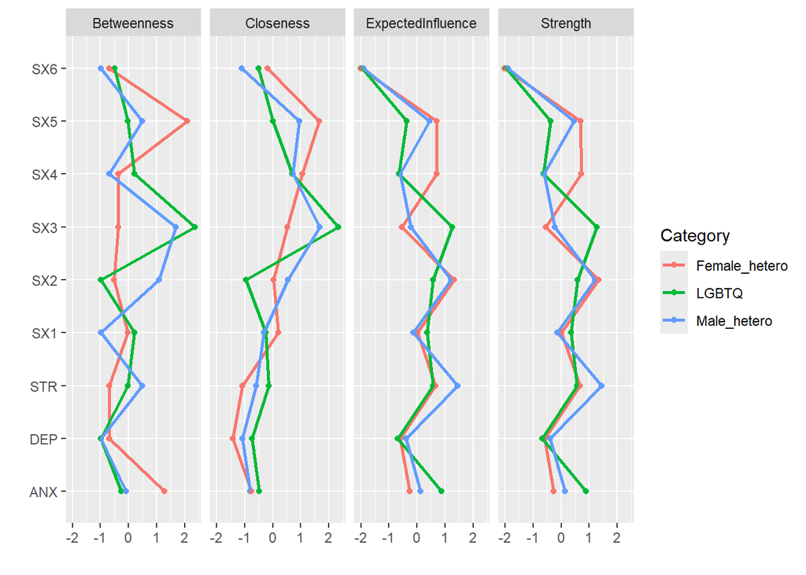

```r
cent_males <- as_tibble(centralityTable(network_males_hetero))

cent_females <- as_tibble(centralityTable(network_female_hetero))

cent_LGBTQ <- as_tibble(centralityTable(network_LGBTQ))

## Plot centrality indices
cent_males$Category <- "Male_hetero"
cent_females$Category <- "Female_hetero"
cent_LGBTQ$Category <- "LGBTQ"
many_BDF <- list(cent_females, cent_males, cent_LGBTQ)
Gender <- as_tibble(Reduce(function(...) merge(..., all = T), many_BDF))

write.csv(Gender, file = "Gender_centrality_index.csv")

Gender <- read.csv("Gender_centrality_index.csv")

Gender %>%
    ggplot(aes(x = node, y = value, color = Category, group = Category)) + geom_point() +
    geom_line(size = 1) + coord_flip() + facet_wrap(~measure, nrow = 1) + labs(x = "",
    y = "")
```

```r
## Write excel files with correlation matrices for males and females
cor_mat_males <- as_tibble(getWmat(network_males_hetero))
write_csv(cor_mat_males, "Correlation matrix male_hetero.csv")
cor_mat_females <- as_tibble(getWmat(network_female_hetero))
write_csv(cor_mat_females, "Correlation matrix female_hetero.csv")
cor_mat_LGBTQ <- as_tibble(getWmat(network_LGBTQ))
write_csv(cor_mat_LGBTQ, "Correlation matrix LGBTQ.csv")
```

#Plot Bridge symptoms

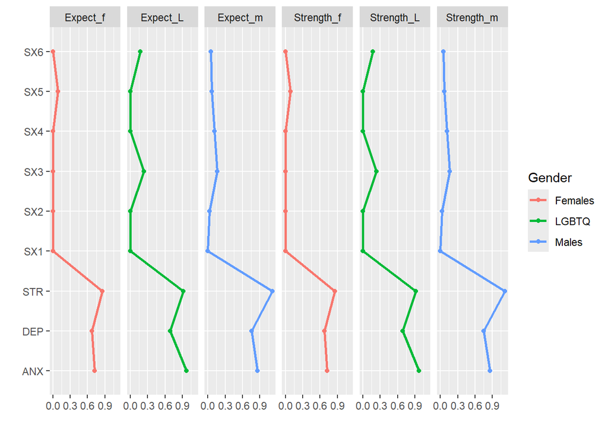

```r
## Prepping male_hetero data frame
graph_males <- qgraph::EBICglasso(cor(Male_hetero), n=dim(Male_hetero)[1])
 b_males <- bridge(graph_males, communities = groups1)
 Strength_m <-  b_males$`Bridge Strength`

 Expect_m <-  b_males$`Bridge Expected Influence (1-step)`
Bsymptoms_m <- Male_hetero%>%
  pivot_longer(cols = c(1:9), names_to = "symptoms", values_to = "n")%>%
  select(symptoms) %>%
  slice_head(n=9)

 symptoms_m <- tibble::tibble(
  Bsymptoms_m,
  Strength_m,

  Expect_m
) %>%
  mutate(
    `Bridge strength` = (Strength_m - mean(Strength_m)) / sd(Strength_m),

    `Bridge expect inf` = (Expect_m - mean(Expect_m)) / sd(Expect_m)
  ) %>%
  tidyr::pivot_longer(
    cols = c(Strength_m,  Expect_m),
    names_to = "Bcent",
    values_to = "n"
  )


## Prepping female_hetero data frame
graph_females <- qgraph::EBICglasso(cor(Female_hetero), n=dim(Female_hetero)[1])
b_females <- bridge(graph_females, communities = groups1)
Strength_f <- b_females$`Bridge Strength`

Expect_f <- b_females$`Bridge Expected Influence (1-step)`
Bsymptoms_f <- Female_hetero%>%
  pivot_longer(cols = c(1:9), names_to = "symptoms", values_to = "n")%>%
  select(symptoms) %>%
  slice_head(n=9)


symptoms_f <- tibble::tibble(
  Bsymptoms_f,
  Strength_f,

  Expect_f
) %>%
  mutate(
    `Bridge strength` = (Strength_f - mean(Strength_f)) / sd(Strength_f),

    `Bridge expect inf` = (Expect_f - mean(Expect_f)) / sd(Expect_f)
  ) %>%
  tidyr::pivot_longer(
    cols = c(Strength_f, Expect_f),
    names_to = "Bcent",
    values_to = "n"
  )


## Prepping LGBTQ data frame
graph_LGBTQ <- qgraph::EBICglasso(cor(LGBTQ), n=dim(LGBTQ)[1])
b_LGBTQ <- bridge(graph_LGBTQ, communities = groups1)
Strength_L <- b_LGBTQ$`Bridge Strength`

Expect_L <- b_LGBTQ$`Bridge Expected Influence (1-step)`
Bsymptoms_L <- LGBTQ%>%
  pivot_longer(cols = c(1:9), names_to = "symptoms", values_to = "n")%>%
  select(symptoms) %>%
  slice_head(n=9)


symptoms_L <- tibble::tibble(
  Bsymptoms_L,
  Strength_L,

  Expect_L
) %>%
  mutate(
    `Bridge strength` = (Strength_L - mean(Strength_L)) / sd(Strength_L),

    `Bridge expect inf` = (Expect_L - mean(Expect_L)) / sd(Expect_L)
  ) %>%
  tidyr::pivot_longer(
    cols = c(Strength_L,  Expect_L),
    names_to = "Bcent",
    values_to = "n"
  )




## Plot centrality indices
symptoms_m$Gender <- 'Males'
symptoms_f$Gender <- 'Females'
symptoms_L$Gender <- 'LGBTQ'
Brian_many_SDF_bridge <- list(symptoms_m,symptoms_f, symptoms_L)
B_bridge_Gender <- as_tibble(Reduce(function(...) merge(..., all=T), Brian_many_SDF_bridge))

write.csv(B_bridge_Gender, file = "Bridge Centrality.csv")

B_bridge_Gender <- read.csv("Bridge Centrality.csv")

B_bridge_Gender %>%
  ggplot(aes(x = symptoms,  y = n, color = Gender, group = Gender)) +
  geom_point() +
  geom_line(size=1.0) +
  coord_flip() +
  facet_wrap(~Bcent, nrow = 1)+
  labs(x = "", y = "")
```

#Hill climbing algorithm is used to learn/determine the initial structure of the Bayesian network

```
##
##   Bayesian network learned via Score-based methods
##
##   model:
##    [SX1][SX2|SX1][SX5|SX1:SX2][SX6|SX5][SX3|SX2:SX5:SX6][SX4|SX2:SX3:SX5:SX6]
##    [ANX|SX3:SX4:SX5][STR|SX3:ANX][DEP|SX3:ANX:STR]
##   nodes:                                 9
##   arcs:                                  19
##     undirected arcs:                     0
##     directed arcs:                       19
##   average markov blanket size:           4.44
##   average neighbourhood size:            4.22
##   average branching factor:              2.11
##
##   learning algorithm:                    Hill-Climbing
##   score:                                 BIC (Gauss.)
##   penalization coefficient:              3.135494
##   tests used in the learning procedure:  220
##   optimized:                             TRUE
```

#Hill climbing algorithm is used to learn/determine the initial structure of the Bayesian network

```
##
##   Bayesian network learned via Score-based methods
##
##   model:
##    [SX1][SX2|SX1][SX3|SX2][SX4|SX2:SX3][SX5|SX1:SX4][SX6|SX4:SX5][ANX|SX5]
##    [STR|ANX][DEP|ANX:STR]
##   nodes:                                 9
##   arcs:                                  12
##     undirected arcs:                     0
##     directed arcs:                       12
##   average markov blanket size:           2.89
##   average neighbourhood size:            2.67
##   average branching factor:              1.33
##
##   learning algorithm:                    Hill-Climbing
##   score:                                 BIC (Gauss.)
##   penalization coefficient:              2.675929
##   tests used in the learning procedure:  132
##   optimized:                             TRUE
```

#Hill climbing algorithm is used to learn/determine the initial structure of the Bayesian network

```
##
##   Bayesian network learned via Score-based methods
##
##   model:
##    [SX1][SX2|SX1][SX3|SX1:SX2][SX4|SX3][ANX|SX3][SX5|SX2:SX4][STR|SX3:ANX]
##    [SX6|SX5:ANX][DEP|ANX:STR]
##   nodes:                                 9
##   arcs:                                  13
##     undirected arcs:                     0
##     directed arcs:                       13
##   average markov blanket size:           3.33
##   average neighbourhood size:            2.89
##   average branching factor:              1.44
##
##   learning algorithm:                    Hill-Climbing
##   score:                                 BIC (Gauss.)
##   penalization coefficient:              2.633929
##   tests used in the learning procedure:  140
##   optimized:                             TRUE
```

#Networks are bootstrapped with 200 iterations to obtain a stable network. Bootstrapped networks can then be saved. Results exported to csv for further analysis in excel

```r
# BSThcMale <- boot.strength(bn_male_data, R = 200, algorithm = 'hc', debug =
# TRUE, cpdag = TRUE)

# saveRDS(BSThcMale, file = 'BSThcMale.RDS')
BSThcMale <- readRDS("BSThcMale.RDS")

# write.csv(BSThcMale, file = 'BSThcMale.csv')

# BSThcFemale <- boot.strength(bn_female_data, R = 200, algorithm = 'hc', debug
# = TRUE, cpdag = TRUE)

# saveRDS(BSThcFemale, file = 'BSThcFemale.RDS')
BSThcFemale <- readRDS("BSThcFemale.RDS")

# write.csv(BSThcFemale, file = 'BSThcFemale.csv')

avgnetFemale85 <- averaged.network(BSThcFemale, threshold = 0.85)
avgnetFemale85
```

```
##
##   Random/Generated Bayesian network
##
##   model:
##    [SX1][SX4][STR][SX2|SX1][SX5|SX4][SX6|SX4][DEP|STR][ANX|STR][SX3|SX2:SX4]
##   nodes:                                 9
##   arcs:                                  7
##     undirected arcs:                     0
##     directed arcs:                       7
##   average markov blanket size:           1.78
##   average neighbourhood size:            1.56
##   average branching factor:              0.78
##
##   generation algorithm:                  Model Averaging
##   significance threshold:                0.85
```

```r
# BSThcLGBTQ <- boot.strength(bn_LGBTQ_data, R = 200, algorithm = 'hc', debug =
# TRUE, cpdag = TRUE)

# saveRDS(BSThcLGBTQ, file = 'BSThcLGBTQ.RDS')
BSThcLGBTQ <- readRDS("BSThcLGBTQ.RDS")

# write.csv(BSThcLGBTQ, file = 'BSThcLGBTQ.csv')
```

#Network is averaged using Scutari’s (2010) method of discerning edge significance

```r
avgnet_scutari_m <- averaged.network(BSThcMale)
avgnet_scutari_m
```

```
##
##   Random/Generated Bayesian network
##
##   model:
##    [SX2][DEP][SX5|SX2][SX1|SX2:SX5][SX6|SX5][SX3|SX2:SX5:SX6:DEP]
##    [SX4|SX2:SX5:SX6:DEP][STR|SX3][ANX|SX4:STR]
##   nodes:                                 9
##   arcs:                                  15
##     undirected arcs:                     0
##     directed arcs:                       15
##   average markov blanket size:           4.44
##   average neighbourhood size:            3.33
##   average branching factor:              1.67
##
##   generation algorithm:                  Model Averaging
##   significance threshold:                0.495
```

```r
avgnet_scutari_f <- averaged.network(BSThcFemale)
avgnet_scutari_f
```

```
##
##   Random/Generated Bayesian network
##
##   model:
##    [SX1][SX4][STR][SX2|SX1:SX4][SX5|SX1:SX4][DEP|STR][SX3|SX2:SX4][SX6|SX4:SX5]
##    [ANX|DEP:STR]
##   nodes:                                 9
##   arcs:                                  11
##     undirected arcs:                     0
##     directed arcs:                       11
##   average markov blanket size:           2.67
##   average neighbourhood size:            2.44
##   average branching factor:              1.22
##
##   generation algorithm:                  Model Averaging
##   significance threshold:                0.59
```

```r
avgnet_scutari_L <- averaged.network(BSThcLGBTQ)
avgnet_scutari_L
```

```
##
##   Random/Generated Bayesian network
##
##   model:
##    [SX2][STR][SX3|SX2:STR][ANX|STR][SX1|SX3][SX4|SX3][DEP|ANX:STR][SX5|SX4]
##    [SX6|SX5:ANX]
##   nodes:                                 9
##   arcs:                                  10
##     undirected arcs:                     0
##     directed arcs:                       10
##   average markov blanket size:           2.67
##   average neighbourhood size:            2.22
##   average branching factor:              1.11
##
##   generation algorithm:                  Model Averaging
##   significance threshold:                0.515
```

#Plot heterosexual male DAG

```r
bayesianNetwork.boot.strength = BSThcMale
#boot.strength(Males, R = 200, algorithm = "hc")
##boot.strength command not used as we have already conducted hill climbing algorithm and conducted bootstrapping separately. Alternatively, boot.strength command can be used to obtain the network and conduct bootstrapping. Other algorithms can also be used to obtain the network. By performing these tasks separately, we are able to save progress along the way and avoid rerunning these processes.

avg.bayesianNetwork = averaged.network(bayesianNetwork.boot.strength, threshold = 0.495)



strength.viewer(
    avg.bayesianNetwork,
    bayesianNetwork.boot.strength,
    bayesianNetwork.background = "white",
    bayesianNetwork.arc.strength.threshold.expression = c("@threshold > 0 & @threshold < 0.85",
                                "@threshold >= 0.85 & @threshold <= 0.90",
                                "@threshold > 0.90 & @threshold <= 1"),

    bayesianNetwork.arc.strength.threshold.expression.color  = c("grey", "light blue", "blue"),
    bayesianNetwork.arc.strength.threshold.alternative.color =  "white",

    bayesianNetwork.arc.strength.tooltip = T,
    #bayesianNetwork.enabled.interactive.mode = TRUE, ##Enables an interactive viewer module for data visualisation

    bayesianNetwork.edge.scale.min = .1,
    bayesianNetwork.edge.scale.max = 5,

    bayesianNetwork.arc.strength.label = F,
    bayesianNetwork.edge.scale.label.min = 12,
    bayesianNetwork.edge.scale.label.max = 12,
    node.shape = "circle",
    node.size = 72,
    node.colors = list(background = "#97c2fc",
                     border = "black",
                     highlight = list(background = "#e91eba",
                                      border = "#2b7ce9")),
node.label.prefix = "",
  node.font = list(color = "black", face="source sans pro black"),

#clusters.legend.title = list(text = clusters.legend.title,
#                                    style = "font-size:18px;
#                                             font-family:Arial;
#                                             color:black;
#                                             text-align:center;"),
clusters.legend.options = list(
  list(label = "BYSAS",
       shape = "icon",
       icon = list(code = "f10c", size = 72, color = "pink")   ),
    list(label = "Depression",
       shape = "icon",
       icon = list(code = "f10c", size = 72, color = "lightblue")   ) ,
    list(label = "Anxiety",
       shape = "icon",
       icon = list(code = "f10c", size = 72, color = "orange")   ) ,
    list(label = "Stress",
       shape = "icon",
       icon = list(code = "f10c", size = 72, color = "grey")   )
  ),

clusters = list(
  list(label = "BYSAS",
      shape = "icon",
       icon = list(code = "f10c", size = 72, color = "pink"),
       nodes = list("SX1", "SX2", "SX3", "SX4", "SX5", "SX6")),
  list(label = "Depression",
      shape = "icon",
       icon = list(code = "f10c", size = 72, color = "lightblue"),
       nodes = list("DEP")),
  list(label = "Anxiety",
      shape = "icon",
       icon = list(code = "f10c", size = 72, color = "orange"),
       nodes = list("ANX")),
  list(label = "Stress",
      shape = "icon",
       icon = list(code = "f10c", size = 72, color = "grey"),
       nodes = list("STR"))

  ),

    bayesianNetwork.width = "100%",
    bayesianNetwork.height = "600px",
    bayesianNetwork.layout = "layout_nicely")
```

[interactive chart not shown]

```r
##Alternate layout options and arguments available at http://robsonfernandes.net/bnviewer/#documentation
```

#Plot heterosexual female DAG

```r
bayesianNetwork.boot.strength = BSThcFemale
#boot.strength(Males, R = 200, algorithm = "hc")
##boot.strength command not used as we have already conducted hill climbing algorithm and conducted bootstrapping separately. Alternatively, boot.strength command can be used to obtain the network and conduct bootstrapping. Other algorithms can also be used to obtain the network. By performing these tasks separately, we are able to save progress along the way and avoid rerunning these processes.

avg.bayesianNetwork = averaged.network(bayesianNetwork.boot.strength, threshold = 0.59)



strength.viewer(
    avg.bayesianNetwork,
    bayesianNetwork.boot.strength,
    bayesianNetwork.background = "white",
    bayesianNetwork.arc.strength.threshold.expression = c("@threshold > 0 & @threshold < 0.85",
                                "@threshold >= 0.85 & @threshold <= 0.90",
                                "@threshold > 0.90 & @threshold <= 1"),

    bayesianNetwork.arc.strength.threshold.expression.color  = c("grey", "light blue", "blue"),
    bayesianNetwork.arc.strength.threshold.alternative.color =  "white",

    bayesianNetwork.arc.strength.tooltip = T,
    #bayesianNetwork.enabled.interactive.mode = TRUE, ##Enables an interactive viewer module for data visualisation

    bayesianNetwork.edge.scale.min = .1,
    bayesianNetwork.edge.scale.max = 5,

    bayesianNetwork.arc.strength.label = F,
    bayesianNetwork.edge.scale.label.min = 12,
    bayesianNetwork.edge.scale.label.max = 12,
    node.shape = "circle",
    node.size = 72,
    node.colors = list(background = "#97c2fc",
                     border = "black",
                     highlight = list(background = "#e91eba",
                                      border = "#2b7ce9")),
node.label.prefix = "",
  node.font = list(color = "black", face="source sans pro black"),

#clusters.legend.title = list(text = clusters.legend.title,
#                                    style = "font-size:18px;
#                                             font-family:Arial;
#                                             color:black;
#                                             text-align:center;"),
clusters.legend.options = list(
  list(label = "BYSAS",
       shape = "icon",
       icon = list(code = "f10c", size = 72, color = "pink")   ),
    list(label = "Depression",
       shape = "icon",
       icon = list(code = "f10c", size = 72, color = "lightblue")   ) ,
    list(label = "Anxiety",
       shape = "icon",
       icon = list(code = "f10c", size = 72, color = "orange")   ) ,
    list(label = "Stress",
       shape = "icon",
       icon = list(code = "f10c", size = 72, color = "grey")   )
  ),

clusters = list(
  list(label = "BYSAS",
      shape = "icon",
       icon = list(code = "f10c", size = 72, color = "pink"),
       nodes = list("SX1", "SX2", "SX3", "SX4", "SX5", "SX6")),
  list(label = "Depression",
      shape = "icon",
       icon = list(code = "f10c", size = 72, color = "lightblue"),
       nodes = list("DEP")),
  list(label = "Anxiety",
      shape = "icon",
       icon = list(code = "f10c", size = 72, color = "orange"),
       nodes = list("ANX")),
  list(label = "Stress",
      shape = "icon",
       icon = list(code = "f10c", size = 72, color = "grey"),
       nodes = list("STR"))

  ),


    bayesianNetwork.width = "100%",
    bayesianNetwork.height = "600px",
    bayesianNetwork.layout = "layout_nicely")
```

[interactive chart not shown]

```r
##Alternate layout options and arguments available at http://robsonfernandes.net/bnviewer/#documentation
```

#Plot LGBTQ DAG

```r
bayesianNetwork.boot.strength = BSThcLGBTQ
#boot.strength(Males, R = 200, algorithm = "hc")
##boot.strength command not used as we have already conducted hill climbing algorithm and conducted bootstrapping separately. Alternatively, boot.strength command can be used to obtain the network and conduct bootstrapping. Other algorithms can also be used to obtain the network. By performing these tasks separately, we are able to save progress along the way and avoid rerunning these processes.

avg.bayesianNetwork = averaged.network(bayesianNetwork.boot.strength, threshold = 0.515)



strength.viewer(
    avg.bayesianNetwork,
    bayesianNetwork.boot.strength,
    bayesianNetwork.background = "white",
    bayesianNetwork.arc.strength.threshold.expression = c("@threshold > 0 & @threshold < 0.85",
                                "@threshold >= 0.85 & @threshold <= 0.90",
                                "@threshold > 0.90 & @threshold <= 1"),

    bayesianNetwork.arc.strength.threshold.expression.color  = c("grey", "light blue", "blue"),
    bayesianNetwork.arc.strength.threshold.alternative.color =  "white",

    bayesianNetwork.arc.strength.tooltip = T,
    #bayesianNetwork.enabled.interactive.mode = TRUE, ##Enables an interactive viewer module for data visualisation

    bayesianNetwork.edge.scale.min = .1,
    bayesianNetwork.edge.scale.max = 5,

    bayesianNetwork.arc.strength.label = F,
    bayesianNetwork.edge.scale.label.min = 12,
    bayesianNetwork.edge.scale.label.max = 12,
    node.shape = "circle",
    node.size = 72,
    node.colors = list(background = "#97c2fc",
                     border = "black",
                     highlight = list(background = "#e91eba",
                                      border = "#2b7ce9")),
node.label.prefix = "",
  node.font = list(color = "black", face="source sans pro black"),

#clusters.legend.title = list(text = clusters.legend.title,
#                                    style = "font-size:18px;
#                                             font-family:Arial;
#                                             color:black;
#                                             text-align:center;"),
clusters.legend.options = list(
  list(label = "BYSAS",
       shape = "icon",
       icon = list(code = "f10c", size = 72, color = "pink")   ),
    list(label = "Depression",
       shape = "icon",
       icon = list(code = "f10c", size = 72, color = "lightblue")   ) ,
    list(label = "Anxiety",
       shape = "icon",
       icon = list(code = "f10c", size = 72, color = "orange")   ) ,
    list(label = "Stress",
       shape = "icon",
       icon = list(code = "f10c", size = 72, color = "grey")   )
  ),

clusters = list(
  list(label = "BYSAS",
      shape = "icon",
       icon = list(code = "f10c", size = 72, color = "pink"),
       nodes = list("SX1", "SX2", "SX3", "SX4", "SX5", "SX6")),
  list(label = "Depression",
      shape = "icon",
       icon = list(code = "f10c", size = 72, color = "lightblue"),
       nodes = list("DEP")),
  list(label = "Anxiety",
      shape = "icon",
       icon = list(code = "f10c", size = 72, color = "orange"),
       nodes = list("ANX")),
  list(label = "Stress",
      shape = "icon",
       icon = list(code = "f10c", size = 72, color = "grey"),
       nodes = list("STR"))

  ),


    bayesianNetwork.width = "100%",
    bayesianNetwork.height = "600px",
    bayesianNetwork.layout = "layout_nicely")
```

[interactive chart not shown]

```r
##Alternate layout options and arguments available at http://robsonfernandes.net/bnviewer/#documentation
```